# GROUP 4 - DAMO 520 - Marketing Analytics - Graded Assignment 2

Tayo Noah Abe, Nihal Vellaramkallingal Sulaiman, Olamide Ibukun

2025-08-08

# STEP Zero — Set up

```r
# install.packages(c("readxl","dplyr","ggplot2","stringr","tidyr","lmtest","car","broom","readr"))

library(readxl)
library(dplyr)
library(ggplot2)
library(stringr)
library(tidyr)
library(lmtest)  # bptest
library(car)     # vif
library(broom)   # tidy model summaries
library(readr)   # write_csv
library(ggplot2)
library(viridisLite)   # palettes
library(viridis)       # scale_*_viridis* helpers
library(tibble)
```

# Step 1

We read the file without skipping any rows so we can use the first data row (full question text) to reliably find the right columns. We then drop that label row.

```r
# Step 1 – Load data & capture the label row
df_raw <- read_excel("Purchasing_data.xlsx", sheet = "Sheet1", col_names = TRUE)

# First row contains full survey questions / labels
labels <- as.character(df_raw[1, ])
purchasing_clean   <- df_raw[-1, ]

dim(df_raw); dim(purchasing_clean)  # raw vs. after dropping label row
```

```
## [1] 4363   89
```

```
## [1] 4362   89
```

```r
# Look at first rows and column names
head(purchasing_clean)
```

```
## # A tibble: 6 × 89
##   Q1     `End Date` Q01_1 Q01_2 Q01_3 Q01_4 Q01_5 Q01_6 Q01_7 Q01_8 Q01_9 Q01_10
##   <chr>  <chr>      <chr> <chr> <chr> <chr> <chr> <chr> <chr> <chr> <chr> <chr>
## 1 44454… 44454.397… Cash  Check Cred… Debi… Elec… 0     0     PayP… Anot… Apple…
## 2 44454… 44454.397… Cash  Check Cred… Debi… Elec… 0     0     0     0     0
## 3 44454… 44454.402… Cash  Check Cred… Debi… 0     0     Gift… 0     0     0
## 4 44454… 44454.412… 0     0     Cred… Debi… 0     0     Gift… 0     0     0
## 5 44454… 44454.414… Cash  Check Cred… Debi… Elec… Stor… Gift… PayP… 0     0
## 6 44454… 44454.417… Cash  Check Cred… 0     Elec… Stor… Gift… PayP… Anot… Apple…
## # ℹ 77 more variables: Q01_11 <chr>, Q01_12 <chr>, Q01_13 <chr>, Q01_14 <chr>,
## #   Q01_15 <chr>, Q02 <chr>, Q03 <chr>, Q04 <chr>, Q05 <chr>, Q06 <chr>,
## #   Q07_1 <chr>, Q07_2 <chr>, Q07_3 <chr>, Q07_4 <chr>, Q07_5 <chr>,
## #   Q07_6 <chr>, Q10 <chr>, Q11_1 <chr>, Q11_2 <chr>, Q11_3 <chr>, Q11_4 <chr>,
## #   Q12_1 <chr>, Q12_2 <chr>, Q12_3 <chr>, Q12_4 <chr>, Q12_5 <chr>,
## #   Q12_6 <chr>, Q12_7 <chr>, Q12_8 <chr>, Q12_9 <chr>, Q13 <chr>, Q13a <chr>,
## #   Q14 <chr>, C1 <chr>, D01_1 <chr>, D01_4 <chr>, D01_5 <chr>, D01_6 <chr>, …
```

```r
colnames(purchasing_clean)
```

```
##  [1] "Q1"       "End Date" "Q01_1"    "Q01_2"    "Q01_3"    "Q01_4"
##  [7] "Q01_5"    "Q01_6"    "Q01_7"    "Q01_8"    "Q01_9"    "Q01_10"
## [13] "Q01_11"   "Q01_12"   "Q01_13"   "Q01_14"   "Q01_15"   "Q02"
## [19] "Q03"      "Q04"      "Q05"      "Q06"      "Q07_1"    "Q07_2"
## [25] "Q07_3"    "Q07_4"    "Q07_5"    "Q07_6"    "Q10"      "Q11_1"
## [31] "Q11_2"    "Q11_3"    "Q11_4"    "Q12_1"    "Q12_2"    "Q12_3"
## [37] "Q12_4"    "Q12_5"    "Q12_6"    "Q12_7"    "Q12_8"    "Q12_9"
## [43] "Q13"      "Q13a"     "Q14"      "C1"       "D01_1"    "D01_4"
## [49] "D01_5"    "D01_6"    "D01_7"    "D01_8"    "D01_9"    "D01_10"
## [55] "D01_11"   "D01_12"   "D02_1"    "D02_4"    "D02_5"    "D02_6"
## [61] "D02_7"    "D02_8"    "D02_9"    "D02_10"   "D02_11"   "D02_12"
## [67] "D02_13"   "D02_14"   "D03_1"    "D03_4"    "D03_5"    "D03_6"
## [73] "D03_7"    "D03_8"    "D03_9"    "D03_10"   "D04_1"    "D04_2"
## [79] "D06"      "D07"      "D08"      "D09"      "D10"      "D11"
## [85] "D12"      "D13"      "D14"      "D15"      "D16"
```

# Step 2 – Robust column finders (by label text)

These patterns helps in matching question text in the label row, so it works even if coded names (Q01_1, D11, etc.) move.

```r
# --- STEP 2 (Robust column matching + fallbacks + sanity table) ---
library(stringr); library(tibble); library(dplyr)

# Expect: labels = as.character(df_raw[1, ]), df_raw[-1, ] is the data body
stopifnot(exists("labels"), exists("df_raw"))

# Never use the name `data` (it masks base::data)
df <- df_raw[-1, , drop = FALSE]
labels <- as.character(labels)

# Guards
stopifnot(is.data.frame(df))
stopifnot(length(labels) == ncol(df))

find_by_label <- function(pat, labels, ignore_case = TRUE) {
  hit <- which(str_detect(labels, regex(pat, ignore_case = ignore_case)))
  if (length(hit) == 0) return(NA_integer_)
  hit[1]
}

# Regex patterns (broad but targeted)
pat_cc_pct   <- "percent(age)?\\s+of\\s+your\\s+purchases.*past\\s*30\\s*days.*credit\\s*card"
pat_numcards <- "total\\s+number\\s+of\\s+credit\\s+cards\\s+you\\s+currently\\s+own"
pat_yob      <- "\\byear\\s+of\\s+birth\\b"
pat_income   <- "approximate\\s+total\\s+personal\\s+income|considering\\s+all\\s+sources\\s+of\\s+income"
pat_savings  <- "about\\s+how\\s+much.*savings.*emergency\\s+expenses"
pat_prime    <- "are\\s+you\\s+currently\\s+subscribed.*amazon\\s*prime"

ix_cc       <- find_by_label(pat_cc_pct, labels)
ix_cards    <- find_by_label(pat_numcards, labels)
ix_yob      <- find_by_label(pat_yob, labels)
ix_income   <- find_by_label(pat_income, labels)
ix_savings  <- find_by_label(pat_savings, labels)
ix_prime    <- find_by_label(pat_prime, labels)

# Fallbacks (1-based)
if (is.na(ix_cc))      ix_cc      <- 21
if (is.na(ix_cards))   ix_cards   <- 18
if (is.na(ix_yob))     ix_yob     <- 80
if (is.na(ix_income))  ix_income  <- 84
if (is.na(ix_savings)) ix_savings <- 89
if (is.na(ix_prime))   ix_prime   <- 77

# Bounds check helper
chk_idx <- function(i, n) {
  if (!is.numeric(i) || length(i) != 1 || is.na(i) || i < 1 || i > n)
    stop("Column index out of range: ", i, " (ncol=", n, ")")
  i
}
ix_cc      <- chk_idx(ix_cc,      ncol(df))
ix_cards   <- chk_idx(ix_cards,   ncol(df))
ix_yob     <- chk_idx(ix_yob,     ncol(df))
ix_income  <- chk_idx(ix_income,  ncol(df))
ix_savings <- chk_idx(ix_savings, ncol(df))
ix_prime   <- chk_idx(ix_prime,   ncol(df))

# Sanity table
matched <- tibble::tibble(
  role    = c("DV: cc_pct","num_cards","year_of_birth","income (text)","savings (text)","Amazon Prime"),
  index   = c(ix_cc, ix_cards, ix_yob, ix_income, ix_savings, ix_prime),
  colname = c(names(df)[ix_cc], names(df)[ix_cards], names(df)[ix_yob],
              names(df)[ix_income], names(df)[ix_savings], names(df)[ix_prime]),
  label_snippet = substr(labels[c(ix_cc, ix_cards, ix_yob, ix_income, ix_savings, ix_prime)], 1, 75)
)
print(matched)
```

```
## # A tibble: 6 × 4
##   role           index colname label_snippet
##   <chr>          <int> <chr>   <chr>
## 1 DV: cc_pct        21 Q05     "Considering all the ways you use credit cards—f…
## 2 num_cards         18 Q02     "What is the total number of credit cards you cu…
## 3 year_of_birth     80 D07     "Year of birth"
## 4 income (text)     84 D11     "Considering all sources of income—such as wages…
## 5 savings (text)    89 D16     "About how much do you currently have in persona…
## 6 Amazon Prime      77 D04_1   "Are you currently subscribed to Amazon Prime, W…
```

```r
# Quick peek at the first few non-NA values for each matched column
peek_vals <- function(v) {
  x <- as.character(v)
  x <- x[!is.na(x) & nzchar(x)]
  head(x, 3)
}

cat("\nSample values (first 3 non-missing):\n")
```

```
##
## Sample values (first 3 non-missing):
```

```r
cat("  cc_pct   :", paste(peek_vals(df[[ix_cc]]), collapse = " | "), "\n")
```

```
##   cc_pct   : Less than 20 percent | Less than 20 percent | Less than 20 percent
```

```r
cat("  num_cards:", paste(peek_vals(df[[ix_cards]]), collapse = " | "), "\n")
```

```
##   num_cards: One | Two | Two
```

```r
cat("  yob      :", paste(peek_vals(df[[ix_yob]]), collapse = " | "), "\n")
```

```
##   yob      : 1995 | 1968 | 1956
```

```r
cat("  income   :", paste(peek_vals(df[[ix_income]]), collapse = " | "), "\n")
```

```
##   income   : Between $25,000 and $49,999 | More than $100,000 | Between $75,000 and $99,999
```

```r
cat("  savings  :", paste(peek_vals(df[[ix_savings]]), collapse = " | "), "\n")
```

```
##   savings  : I have no savings. | Between $2,500 and $5,000 | Between $2,500 and $5,000
```

```r
cat("  prime    :", paste(peek_vals(df[[ix_prime]]), collapse = " | "), "\n")
```

```
##   prime    : Yes | No | Yes
```

# Step 3 – Clean & engineer variables

```r
to_midpoint <- function(x) {
  x <- as.character(x)
  if (length(x) == 0) return(numeric(0))
  nums <- stringr::str_extract_all(x, "[0-9][0-9,]*")
  out <- mapply(function(txt, vec) {
    if (length(vec) == 0) return(NA_real_)
    vals <- as.numeric(gsub(",", "", vec))
    txtl <- tolower(txt)
    if (length(vals) >= 2) {
      mean(vals[1:2])                             # "Between $25,000 and $49,999"
    } else if (grepl("less than", txtl)) {
      vals[1] / 2                                  # "Less than $1,000"
    } else if (grepl("more than|over|at least|\\+$", txtl)) {
      vals[1]                                      # "More than $100,000"
    } else if (grepl("no savings|none|i have no savings", txtl)) {
      0
    } else {
      vals[1]
    }
  }, x, nums, USE.NAMES = FALSE)
  as.numeric(out)
}

num_safely <- function(x) as.numeric(gsub("[^0-9.\\-]", "", as.character(x)))

# Require DV to be found
stopifnot(!is.na(ix_cc))

# Small helper: pull a column by its *name* inferred from index
get_col_by_ix <- function(df, ix) {
  if (is.na(ix)) return(rep(NA_character_, nrow(df)))
  df[[ names(df)[ix] ]]
}

# --- Build raw fields from your matched indices (by *name*, not number) ---
raw_df <- tibble::tibble(
  cc_pct_raw   = get_col_by_ix(purchasing_clean, ix_cc),
  cards_raw    = get_col_by_ix(purchasing_clean, ix_cards),
  yob_raw      = get_col_by_ix(purchasing_clean, ix_yob),
  income_txt   = get_col_by_ix(purchasing_clean, ix_income),
  savings_txt  = get_col_by_ix(purchasing_clean, ix_savings),
  prime_raw    = get_col_by_ix(purchasing_clean, ix_prime)
)

# --- Create the analytic dataset used in modeling/plots ---
analytic <- raw_df %>%
  dplyr::transmute(
    cc_pct      = num_safely(cc_pct_raw),                 # DV: 0–100
    num_cards   = num_safely(cards_raw),
    yob         = num_safely(yob_raw),
    age         = dplyr::if_else(!is.na(yob), 2025 - yob, as.numeric(NA)),
    income_mid  = to_midpoint(income_txt),
    savings_mid = to_midpoint(savings_txt),
    prime_sub   = dplyr::case_when(
      is.na(prime_raw) ~ as.numeric(NA),
      stringr::str_detect(tolower(as.character(prime_raw)), "yes|selected|amazon|1|true") ~ 1,
      TRUE ~ 0
    )
  )

# --- Replace num_cards parsing with a robust textual parser ---
if (exists("ix_cards") && !is.na(ix_cards)) {
  # Use the column you already extracted (avoid the name 'data' entirely)
  stopifnot(exists("raw_df"))
  cards_txt <- as.character(raw_df$cards_raw)  # or: as.character(purchasing_clean[[ix_cards]])

  # Normalize
  cards_low <- tolower(trimws(cards_txt))

  # 1) Extract first digit if present (e.g., "2 cards", "3+")
  cards_num <- suppressWarnings(as.numeric(stringr::str_extract(cards_low, "\\d+")))

  # 2) Handle common words
  words_map <- c(
    "none" = 0, "no" = 0, "zero" = 0,
    "one" = 1, "two" = 2, "three" = 3, "four" = 4,
    "five" = 5, "six" = 6, "seven" = 7, "eight" = 8, "nine" = 9
  )

  need_word <- is.na(cards_num) & nzchar(cards_low)
  if (any(need_word)) {
    word_only <- gsub("[^a-z]+", " ", cards_low[need_word])
    word_only <- trimws(word_only)
    wnum <- rep(NA_real_, sum(need_word))
    for (w in names(words_map)) {
      hit <- grepl(paste0("\\b", w, "\\b"), word_only)
      wnum[hit] <- words_map[[w]]
    }
    cards_num[need_word] <- wnum
  }

  # 3) Treat "don't have", "not applicable" etc. as 0
  none_like <- grepl("don'?t.*have|do not.*have|not applicable|n/?a|nil|no card", cards_low)
  cards_num[is.na(cards_num) & none_like] <- 0

  # 4) Assign back into analytic
  analytic$num_cards <- cards_num
} else {
  analytic$num_cards <- NA_real_
}


# Same summary line you had before
summary(dplyr::select(analytic, cc_pct, num_cards, age, income_mid, savings_mid, prime_sub))
```

```
##      cc_pct       num_cards         age           income_mid
##  Min.   :  20   Min.   :0.00   Min.   : 22.00   Min.   : 25000
##  1st Qu.:  80   1st Qu.:2.00   1st Qu.: 40.00   1st Qu.: 37500
##  Median :2040   Median :2.00   Median : 55.00   Median : 62500
##  Mean   :2010   Mean   :2.62   Mean   : 55.03   Mean   : 67478
##  3rd Qu.:4060   3rd Qu.:4.00   3rd Qu.: 69.00   3rd Qu.:100000
##  Max.   :6080   Max.   :5.00   Max.   :100.00   Max.   :100000
##  NA's   :2268   NA's   :1631   NA's   :2268     NA's   :2268
##   savings_mid      prime_sub
##  Min.   :  250   Min.   :0.0000
##  1st Qu.: 1750   1st Qu.:0.0000
##  Median : 7500   Median :1.0000
##  Mean   :11217   Mean   :0.6776
##  3rd Qu.:25000   3rd Qu.:1.0000
##  Max.   :25000   Max.   :1.0000
##  NA's   :2480    NA's   :2268
```

# Handling of missing values per model

We handled missing value by dropping missing rows per model (not globally), so that each model uses the largest valid of sample: Model 1 requires cc_pct and num_cards Multiple/Nonlinear require cc_pct, age, num_cards, income_mid, savings_mid, prime_sub

```r
m1_df <- analytic %>%
  select(cc_pct, num_cards) %>%
  filter(!is.na(cc_pct), !is.na(num_cards))

m2_df <- analytic %>%
  select(cc_pct, age, num_cards, income_mid, savings_mid, prime_sub) %>%
  filter(complete.cases(.))

tibble::tibble(
  frame = c("Model 1 (simple)", "Model 2/3 (multi)"),
  n = c(nrow(m1_df), nrow(m2_df))
)
```

```
## # A tibble: 2 × 2
##   frame                 n
##   <chr>             <int>
## 1 Model 1 (simple)   2094
## 2 Model 2/3 (multi)  1882
```

#Diagnostic

```r
# === DIAGNOSTIC: what do we actually have after Step 3? ===
diag_counts <- sapply(dplyr::select(
  analytic, cc_pct, num_cards, age, income_mid, savings_mid, prime_sub
), function(x) sum(!is.na(x)))

diag_counts  # look here: any zeros?
```

```
##      cc_pct   num_cards         age  income_mid savings_mid   prime_sub
##        2094        2731        2094        2094        1882        2094
```

```r
# Peek first 10 non-missing of each (helps confirm parsing)
peek <- function(v) head(v[!is.na(v)], 10)
list(
  cc_pct     = peek(analytic$cc_pct),
  num_cards  = peek(analytic$num_cards),
  age        = peek(analytic$age),
  income_mid = peek(analytic$income_mid),
  savings_mid= peek(analytic$savings_mid),
  prime_sub  = peek(analytic$prime_sub)
)
```

```
## $cc_pct
##  [1]   20   20   20 2040   20 2040   20   20 4060   20
##
## $num_cards
##  [1] 1 2 2 3 1 2 1 2 1 2
##
## $age
##  [1] 30 57 69 74 73 45 39 57 69 73
##
## $income_mid
##  [1]  37499.5 100000.0  87499.5  25000.0 100000.0  25000.0  25000.0  25000.0
##  [9]  25000.0  25000.0
##
## $savings_mid
##  [1]  3750  3750 25000   250   250  7500   750  3750   250 25000
##
## $prime_sub
##  [1] 1 0 1 0 1 1 1 0 1 0
```

#Step 4 – Exploratory analysis (plots) These will help us to support our variable justification and model choice.

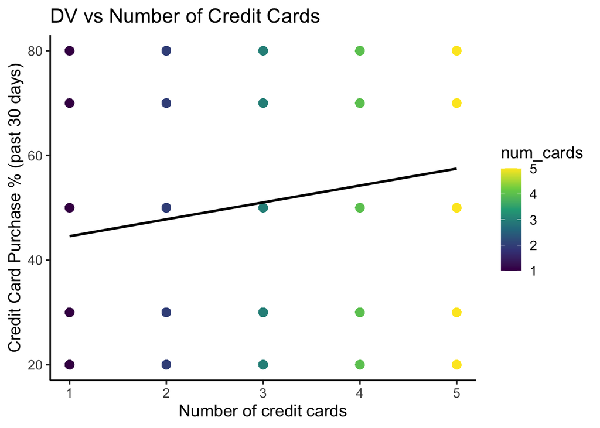

```r
# Recoding cc_pct to 0–100 scale
m1_df <- m1_df %>%
  mutate(cc_pct_clean = case_when(
    cc_pct == 20 ~ 20,
    cc_pct == 2040 ~ 30,
    cc_pct == 4060 ~ 50,
    cc_pct == 6080 ~ 70,
    cc_pct == 80100 ~ 90,
    TRUE ~ as.numeric(cc_pct)  # fallback in case
  ))

# DV vs Number of Credit Cards (using cleaned cc_pct)
if (nrow(m1_df) > 0) {
  ggplot(m1_df, aes(x = num_cards, y = cc_pct_clean, color = num_cards)) +
    geom_point(alpha = 0.6, size = 3) +
    geom_smooth(method = "lm", se = FALSE, color = "black") +
    labs(title = "DV vs Number of Credit Cards",
         x = "Number of credit cards",
         y = "Credit Card Purchase % (past 30 days)") +
    theme_classic(base_size = 14) +
    scale_color_viridis_c()


}
```

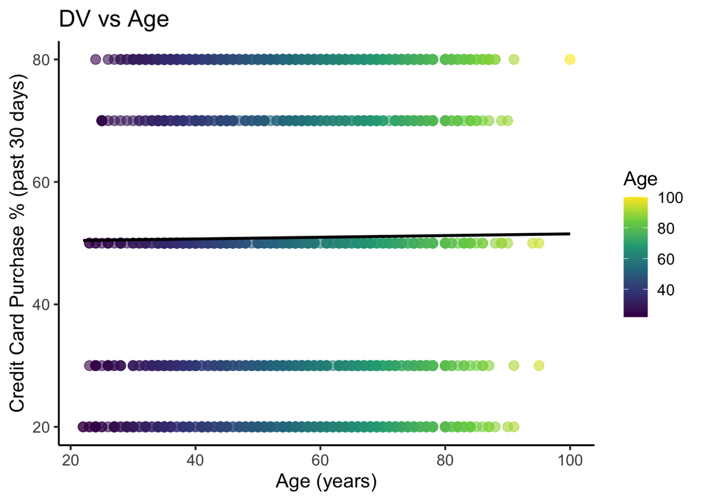

```r
# Recoding cc_pct to 0–100 scale for m2_df
m2_df <- m2_df %>%
  mutate(cc_pct_clean = case_when(
    cc_pct == 20 ~ 20,
    cc_pct == 2040 ~ 30,
    cc_pct == 4060 ~ 50,
    cc_pct == 6080 ~ 70,
    cc_pct == 80100 ~ 90,
    TRUE ~ as.numeric(cc_pct)  # fallback in case
  ))

# DV vs Age (using cleaned cc_pct)
if (nrow(m2_df) > 0) {
  ggplot(m2_df, aes(x = age, y = cc_pct_clean, color = age)) +
    geom_point(alpha = 0.6, size = 3) +
    geom_smooth(method = "lm", se = FALSE, color = "black") +
    labs(title = "DV vs Age",
         x = "Age (years)",
         y = "Credit Card Purchase % (past 30 days)") +
    theme_classic(base_size = 14) +
    scale_color_viridis_c(name = "Age")


}
```